# DSSG Presentation - Erika Martinez

## Transportation network design

Let's imagine that a famous tycoon named Melon Mask has completed his new invention: the hypermegaminiloop. That revolutionizes urban transportation, but at the moment it is very expensive.

The mayor of New York has found out about it and wants to be an *early adopter* of the project and complement (not replace) its transportation network. For this, data is available from [Uber demand](https://data.world/data-society/uber-pickups-in-nyc) that this new method is intended to cover.

A representative but smaller subset of the data is given to prevent its processing from having very long execution times.

```python
#Libraries:

import random

import matplotlib
import matplotlib.pyplot as plt
import numpy as np
import pandas as pd
import sklearn
from sklearn import cluster        # Clustering algorithm
from sklearn.cluster import KMeans
from sklearn.cluster import DBSCAN
from sklearn.cluster import AgglomerativeClustering

import kruskal

import haversine as hs
from haversine import haversine as hs

%matplotlib inline
```

```python
df = pd.read_csv('uber_sample.csv')
df.head(3)
```

|  | Date/Time | Lat | Lon | Base |
| --- | --- | --- | --- | --- |
| 0 | 9/16/2014 5:37:00 | 40.7651 | -73.9615 | B02764 |
| 1 | 9/21/2014 12:12:00 | 40.7249 | -73.9947 | B02764 |
| 2 | 9/22/2014 12:50:00 | 40.7720 | -73.9590 | B02598 |

```python
df.info()
```

```
<class 'pandas.core.frame.DataFrame'>
RangeIndex: 16017 entries, 0 to 16016
Data columns (total 4 columns):
 #   Column     Non-Null Count  Dtype
---  ------     --------------  -----
 0   Date/Time  16017 non-null  object
 1   Lat        16017 non-null  float64
 2   Lon        16017 non-null  float64
 3   Base       16017 non-null  object
dtypes: float64(2), object(2)
memory usage: 500.7+ KB
```

We visualize the data to see where there is a higher concentration of requests and facilitate the subsequent analysis of the data. Can you see *Central Park*?

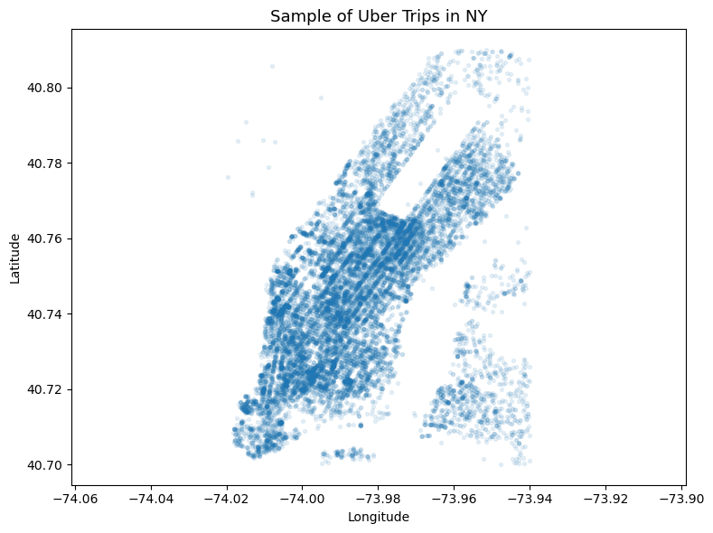

```python
fig, ax = plt.subplots(1, 1, figsize=(8, 6))
ax.scatter(df['Lon'], df['Lat'], s=8, alpha=.1) #The alpha blending value, between 0 (transparent) and 1 (opaque).
ax.set_xlabel('Longitude')
ax.set_ylabel('Latitude')
ax.set_title('Sample of Uber Trips in NY', fontsize=13)
ax.axis('equal')
plt.tight_layout()
plt.show()
```

### a. Stops Location: clustering

The first part of the design of the transportation network is to locate the future stops. To do this, you will have to identify between 100 and 200 places on the map (approximation provided by the city's transportation department) with a high concentration of demand. You can choose any clustering algorithm for this task, but remember that you will have to justify the answer for the project proposal.

**Implementation:** choose and apply a clustering technique to find between 100 and 200 groups of points.

```python
#Create the model
clusteringDBSCAN = DBSCAN(eps=0.0006, min_samples=15)

#Apply the model to the data
clusteringDBSCAN.fit(df[['Lat', 'Lon']])

#The results are saved in labels_, these we put them in a new column in the df called DBSCANClusters
df["DBSCANClusters"] = clusteringDBSCAN.labels_

clusters = clusteringDBSCAN.labels_
print("The number of clusters (including the outliers) is: " + str(len(set(clusters))))
```

```
The number of clusters (including the outliers) is: 146
```

**Implementation:** visualize the groups found by adding color to the points based on the cluster to which they belong.

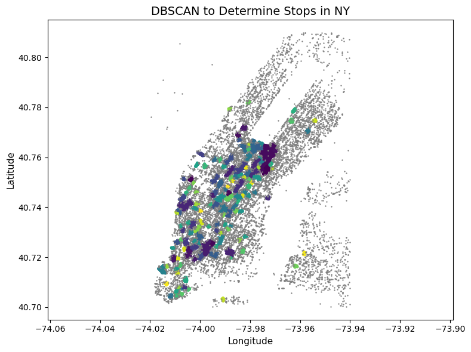

```python
#Separate the outliers from the clusters
outliers_df = df[clusteringDBSCAN.labels_ == -1]
clusters_df = df[clusteringDBSCAN.labels_ != -1]

np.random.seed(10)
color = clusteringDBSCAN.labels_  #Array with the 16017 points with the number of the 146 clusters.
color_clusters = color[color != -1]  #Array with the values of only the clusters
color_outliers = "gray"

#Draw clusters and outliers
fig, ax = plt.subplots(1, 1, figsize=(8, 6))

ax.scatter(clusters_df["Lon"], clusters_df["Lat"], c = color_clusters, s=8)
ax.scatter(outliers_df["Lon"], outliers_df["Lat"], c = color_outliers, s=0.5)

ax.set_xlabel("Longitude", fontsize=11)
ax.set_ylabel("Latitude", fontsize=11)
ax.set_title("DBSCAN to Determine Stops in NY", fontsize=14)

ax.axis('equal')

plt.tight_layout()
plt.show()
```

**Analysis:** Facing the drafting of the project proposal, why did you choose this clustering method?

The clustering method chosen is DBSCAN. As mentioned in the statement, the stops must be located in places with a high concentration of demand, therefore, DBSCAN is suitable for this type of problem since the clusters would be formed based on the density of the points where there is more demand for uber trips . This differs from the use of K-Means, a method that would generate a previously determined number of clusters based on the Euclidean distance, without taking density/demand into account.

### b. Group analysis and data preparation

Before continuing with the design of the transportation network, it is necessary to validate that the clusters make sense. The first thing is to estimate the density of each cluster:

**1.** You can simplify it as: (lat_max - lat_min) * (lon_max - lon_min), be careful with negative values, of the points that belong to the cluster.

**2.** Calculate the number of points that belong to each cluster.

```python
df.head(5)
```

|  | Date/Time | Lat | Lon | Base | DBSCANClusters |
| --- | --- | --- | --- | --- | --- |
| 0 | 9/16/2014 5:37:00 | 40.7651 | -73.9615 | B02764 | -1 |
| 1 | 9/21/2014 12:12:00 | 40.7249 | -73.9947 | B02764 | 2 |
| 2 | 9/22/2014 12:50:00 | 40.7720 | -73.9590 | B02598 | -1 |
| 3 | 9/5/2014 1:32:00 | 40.7259 | -73.9905 | B02617 | -1 |
| 4 | 9/7/2014 9:04:00 | 40.7561 | -73.9731 | B02617 | 0 |

```python
#Calcule the minimun and maximum latitude and longitude of every cluster
#LATITUDE
lat_min = df[['Lat', 'DBSCANClusters']].groupby(by=["DBSCANClusters"]).min()
lat_max = df[['Lat', 'DBSCANClusters']].groupby(by=["DBSCANClusters"]).max()

#LONGITUDE
lon_min = df[['Lon', 'DBSCANClusters']].groupby(by=["DBSCANClusters"]).min()
lon_max = df[['Lon', 'DBSCANClusters']].groupby(by=["DBSCANClusters"]).max()

#Calculate the difference of the minimun and maximun latitude and longitude.
#Transformed to meters (one degree of latitude equals 111 km and one degree of longitude is around 75 km)
Diff_Lat_km = (lat_max - lat_min) * 111
Diff_Lon_km = (lon_max - lon_min) * 75

#Create a new dataframe with the 146 clusters as the index and with the number of points that belong to the cluster in a column
df_Clusters = df[['Base', 'DBSCANClusters']].groupby(by=["DBSCANClusters"]).count()

#Multiply the values of the difference of latitudes and longitudes to get the Areas. Put it in the new dataframe.
df_Clusters["Area"] = Diff_Lat_km["Lat"]*Diff_Lon_km["Lon"]

#Rename the column Base
df_Clusters.rename(columns={"Base": "NumPoints"}, inplace=True,)

df_Clusters
```

| DBSCANClusters | NumPoints | Area |
| --- | --- | --- |
| -1 | 9716 | 72.669757 |
| 0 | 85 | 0.083916 |
| 1 | 53 | 0.016983 |
| 2 | 39 | 0.019814 |
| 3 | 48 | 0.022977 |
| ... | ... | ... |
| 140 | 14 | 0.006743 |
| 141 | 15 | 0.004995 |
| 142 | 17 | 0.006660 |
| 143 | 17 | 0.007326 |
| 144 | 17 | 0.005994 |

146 rows × 2 columns

**3.** Calculate the following ratio: number of points (2) per covered area (1) of each cluster.

```python
#Divide the values of the number of points by the areas of the clusters in squared kilometers.
dfPointsPerArea = df_Clusters['NumPoints'] / df_Clusters['Area']

#The result is the ratio of uber trips per area of the clusters in sq km.
dfPointsPerArea.sort_index()
```

```
DBSCANClusters
-1       133.700735
 0      1012.917680
 1      3120.767827
 2      1968.354910
 3      2089.045567
           ...
 140    2076.150224
 141    3003.003003
 142    2552.552553
 143    2320.502321
 144    2836.169503
Length: 146, dtype: float64
```

**Analysis:** Do you observe any suspicious situation? Analyze it and, if necessary, clean the data for the following steps.

Yes, I do. There was an issue with the distance in degrees, because we got the difference of the latitude and longitude values, but it was not in meters or kilometers. So, I converted the degrees to kilometers. One degree of latitude is 111 km and one degree of longitude at New York is about 75 km. Although the areas of the clusters do not reach 1 square km, I decided to use this measure, otherwise the numbers were too small to be understandable.

Source: https://www.sco.wisc.edu/2022/01/21/how-big-is-a-degree/

### c. Transportation network design

Because the technology is very new and expensive, we have the mandate to make a design that minimizes the extension of the network trying to cover the largest number of requests possible.

Various strategies can be used for this. Among them is the *MST* or [*Minimum Spanning Tree*](https://en.wikipedia.org/wiki/Minimum_spanning_tree) family, with algorithms such as [*Kruskal*](https://en.wikipedia.org/wiki/Kruskal%27s_algorithm) or *Prim*. The *Kruskal* algorithm has the advantage of being very fast because it is *greedy* (suboptimal) and, furthermore, it avoids cycles. An extra benefit, since in our case it would establish redundant links, which we want to avoid due to the high cost.

The steps are the following:

1. Prepare the data for the graph.
2. Apply the Kruskal algorithm.
3. Analyze the results and decide the final design of the network.

**1.** Prepare the data for the graph.

**Implementation:** create a dataframe in which there is one row per cluster and it contains: **id** of the cluster (numeric), **latitude** and **longitude** (representative of the cluster), and **number of points** belonging to the cluster.

```python
#Group by the number of clusters, get the average of the latitude and longitude for every cluster and merge with the number of points
dfMST = df[["DBSCANClusters", 'Lat', 'Lon']].groupby('DBSCANClusters').mean().merge(df_Clusters['NumPoints'], left_index=True, right_index=True)

#Ignore the information of the ourliers (-1)
dfMST_NoOutliers = dfMST.iloc[1:]

#Print
dfMST2 = dfMST_NoOutliers
dfMST2
```

| DBSCANClusters | Lat | Lon | NumPoints |
| --- | --- | --- | --- |
| 0 | 40.755026 | -73.973401 | 85 |
| 1 | 40.751160 | -74.003534 | 53 |
| 2 | 40.725490 | -73.995003 | 39 |
| 3 | 40.745254 | -73.988615 | 48 |
| 4 | 40.760692 | -73.973179 | 520 |
| ... | ... | ... | ... |
| 140 | 40.749700 | -73.979457 | 14 |
| 141 | 40.721600 | -73.958220 | 15 |
| 142 | 40.709382 | -74.013547 | 17 |
| 143 | 40.738588 | -73.999959 | 17 |
| 144 | 40.748329 | -73.988647 | 17 |

145 rows × 3 columns

**2.** Apply the Kruskal algorithm.

To create the undirected graph (if 1 is connected to 2, the reverse direction is assumed) from which the *Kruskal* algorithm will select the links, it is necessary to indicate the possible edges of the graph.

To create the graph, simply instantiate the `Graph` class of the *kruskal* module that we have modified from [here](https://www.pythonpool.com/kruskals-algorithm-python/). Indicating in the `vertex` parameter of its constructor the highest id of cluster +1. Subsequently, edges can be added to the graph, indicating first the two cluster ids that the section joins and finally their weight, which is indicated by the definition of *weight* later on.

Finally, the result of *Kruskal* is calculated over the graph by calling the `kruskal` method, which also has a `max_links` parameter if we only want as many links to be generated as indicated (useful later).

A concrete example would be the following:

```
g = kruskal.Graph(vertex=5)
g.add_edge(0, 1, 8)
...
g.add_edge(3, 4, 7)
g.kruskal()
```

Due to the high cost, it is necessary to justify the construction of each section of the *hypermegaminiloop*, so we are going to use a measure that weighs (*weight*) each section (union between any 2 clusters $i$ and $j$):

$$weight(i, j) = -\frac{n_i+n_j}{dist(i, j)}$$

Where:

- $n_i$ is the number of points in cluster $i$, in the same way $n_j$ is the number of points in cluster $j$.
- $dist(i, j)$ is the geographic distance in km between the center of cluster $i$ and cluster $j$.

The geographical distance between any 2 points is not the Euclidean distance, since the earth has curvature. For this you can use the module [haversine](https://pypi.org/project/haversine/) (already imported as *hs* at the beginning of the assignment).

Finally, note that the final weight is negative because the *Kruskal* algorithm sees this weight as a cost that it tries to minimize. For our part, we want to encourage that the higher the ratio described, the more attractive it is to *Kruskal*, which is why it becomes negative.

**Implementation:** create a graph following the example code in which all the pairs of possible clusters appear (it is not necessary to repeat the pairs because it is an undirected graph where A-B is also equal to B-A), where the weight (last parameter of the add_edge method ) is calculated as described in the weight formula.

```python
#Weight Function
def weight(i, j):

    #Number of points in two clusters
    n1 = dfMST2["NumPoints"][dfMST2.index == i].item()
    n2 = dfMST2["NumPoints"][dfMST2.index == j].item()

    #Distance(i, j)
    point1 = (dfMST2['Lat'][dfMST2.index == i].item(), dfMST2['Lon'][dfMST2.index == i].item())
    point2 = (dfMST2['Lat'][dfMST2.index == j].item(), dfMST2['Lon'][dfMST2.index == j].item())
    haversine = hs(point1, point2)

    result = -(n1+n2)/haversine
    return result


#Apply of the kruskal algorithm
g = kruskal.Graph(vertex=145)

for i in range(145):
    for u in range(145):
        if (i < u):  #To avoid repetition
            g.add_edge(i, u, weight(i, u))

g.kruskal()
```

|  | id_a | id_b | weight |
| --- | --- | --- | --- |
| 0 | 4 | 69 | -2028.398333 |
| 1 | 4 | 60 | -1756.153983 |
| 2 | 4 | 6 | -1567.235598 |
| 3 | 4 | 89 | -1409.798254 |
| 4 | 4 | 43 | -1353.893022 |
| ... | ... | ... | ... |
| 139 | 21 | 87 | -174.925075 |
| 140 | 64 | 142 | -163.362768 |
| 141 | 4 | 141 | -118.211279 |
| 142 | 11 | 130 | -107.578554 |
| 143 | 4 | 112 | -107.193698 |

144 rows × 3 columns

**Implementation:** apply the Kruskal algorithm by calling the kruskal method of the graph, varying the number of axes depending on your criteria (compromise between extension and cost).

```python
g.kruskal(100)
```

|  | id_a | id_b | weight |
| --- | --- | --- | --- |
| 0 | 4 | 69 | -2028.398333 |
| 1 | 4 | 60 | -1756.153983 |
| 2 | 4 | 6 | -1567.235598 |
| 3 | 4 | 89 | -1409.798254 |
| 4 | 4 | 43 | -1353.893022 |
| ... | ... | ... | ... |
| 95 | 7 | 8 | -324.092126 |
| 96 | 4 | 57 | -321.110560 |
| 97 | 11 | 67 | -316.602356 |
| 98 | 4 | 104 | -315.762279 |
| 99 | 24 | 36 | -310.947093 |

100 rows × 3 columns

**3.** Analyze the results and decide the final design of the network.

**Implementation:** Visualize the centers of the clusters indicating their importance (for example increasing their diameter or changing their color depending on the number of points it contains) and their links also indicating their importance (through their thickness or transparency) produced by the Kruskal algorithm.

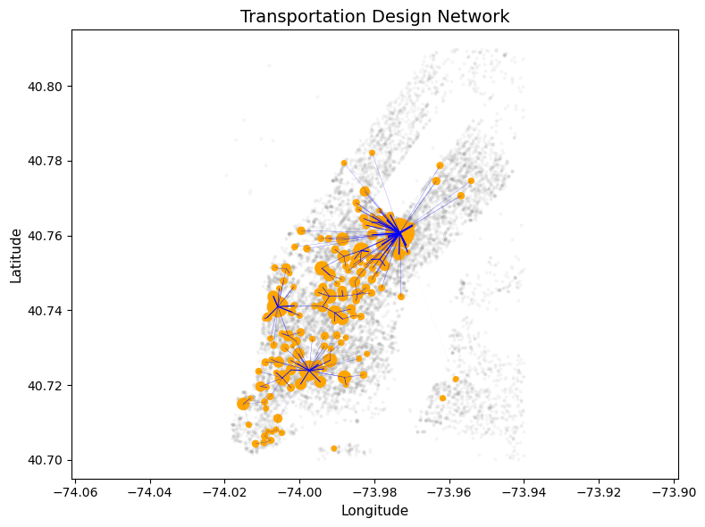

```python
fig, ax = plt.subplots(1, 1, figsize=(8, 6))

#Show the points to visualize the city of NY
ax.scatter(df['Lon'], df['Lat'], s=4, alpha=.05, c="gray")

#Draw the clusters with the size based on the number of points/Uber trips the clusters have.
plt.scatter(x=dfMST2['Lon'],y=dfMST2['Lat'], s=dfMST2['NumPoints'], c= "orange")


#Draw the edges with a width based on the weight.

krus = g.kruskal()

#Create a new column with the weight in positive numbers.
krus["weight_positive"] = -krus["weight"]

for num in range(len(krus)):
    c1 = krus.loc[[num]]['id_a'].item()
    c2 = krus.loc[[num]]['id_b'].item()
    line = (krus.loc[[num]]["weight_positive"].item() - krus["weight_positive"].min()) / (krus["weight_positive"].max() - krus["weight_positive"].min())

    x1 = dfMST2.loc[[c1]]['Lon'].item()
    y1 = dfMST2.loc[[c1]]['Lat'].item()

    x2 = dfMST2.loc[[c2]]['Lon'].item()
    y2 = dfMST2.loc[[c2]]['Lat'].item()

    plt.plot([x1,x2], [y1,y2], linewidth=line*2, color='b')

ax.set_xlabel("Longitude", fontsize=11)
ax.set_ylabel("Latitude", fontsize=11)
ax.set_title("Transportation Design Network", fontsize=14)

ax.axis('equal')
plt.tight_layout()
plt.show()
```